# RD Analysis (Lee,2007)

Matt Goldman

June 28, 2017

# Question 1

Confounding Variables: Unemployment rate in 2008, local gov. budget deficits in 2008,

Variance Reducing Variable: Aggregate economic variables in 2010. The key word here is aggregate because they have to be on large enough a scale that they could not be impacted by one county’s decision to invest in job training (or else it would be a bad control). An exmaples might be state-level GDP data.

Unrelated variables: Avg. obesity level, Most poppular rapper in each Congressional District.

Bad Controls: unemployment in 2009, budget deficits in 2009, almost anything else measured in 2009 or later

## Question 2 - Load Data

```r
setwd('C:/Users/mattgold/Desktop/Lee_2007')
dat=read.csv(file="dataset.csv",header=TRUE)
#dat<-subset(dat,YearElec>1960)
```

# (b)

```r
reg<-lm(DWinNxt~DemWin,data=dat)
summary(reg)
```

```
##
## Call:
## lm(formula = DWinNxt ~ DemWin, data = dat)
##
## Residuals:
##      Min       1Q   Median       3Q      Max
## -0.92374 -0.11397  0.07626  0.07626  0.88603
##
## Coefficients:
##             Estimate Std. Error t value Pr(>|t|)
## (Intercept) 0.113966   0.004292   26.55   <2e-16 ***
## DemWin      0.809775   0.005736  141.18   <2e-16 ***
## ---
## Signif. codes:  0 '***' 0.001 '**' 0.01 '*' 0.05 '.' 0.1 ' ' 1
##
## Residual standard error: 0.2896 on 10348 degrees of freedom
##   (6618 observations deleted due to missingness)
## Multiple R-squared:  0.6583, Adjusted R-squared:  0.6582
## F-statistic: 1.993e+04 on 1 and 10348 DF,  p-value: < 2.2e-16
```

The regression coefficient is huge (.8). This means that a district is 80% more likely to go Democratic if it went Democratic last time. However, there could be many reasons why this is case besides the incumbent effect. There could be permanent characteristics of a district or of the politicans running in that district that make that district likely to vote for Democrats (or not) many times in a row. All of these characteristics would impact the error term and the treatment and thus mean that this regression does NOT represent a natural experiment.

# (c)

DWinPrv, ForgnPct, GovWkPct+ BlackPct+UrbanPct

```r
reg<-lm(DWinNxt~DemWin+DWinPrv+ForgnPct+GovWkPct+ BlackPct+UrbanPct,data=dat)
summary(reg)
```

```
##
## Call:
## lm(formula = DWinNxt ~ DemWin + DWinPrv + ForgnPct + GovWkPct +
##     BlackPct + UrbanPct, data = dat)
##
## Residuals:
##      Min       1Q   Median       3Q      Max
## -1.03030 -0.08954  0.04259  0.08903  0.93207
##
## Coefficients:
##               Estimate Std. Error t value Pr(>|t|)
## (Intercept)  0.0650276  0.0104948   6.196 6.06e-10 ***
## DemWin       0.6926392  0.0113352  61.105  < 2e-16 ***
## DWinPrv      0.1202196  0.0113588  10.584  < 2e-16 ***
## ForgnPct     0.0020632  0.0005946   3.470 0.000523 ***
## GovWkPct    -0.0003046  0.0012748  -0.239 0.811140
## BlackPct     0.0017525  0.0002455   7.138 1.03e-12 ***
## UrbanPct     0.0001836  0.0001450   1.266 0.205407
## ---
## Signif. codes:  0 '***' 0.001 '**' 0.01 '*' 0.05 '.' 0.1 ' ' 1
##
## Residual standard error: 0.2859 on 8262 degrees of freedom
##   (8699 observations deleted due to missingness)
## Multiple R-squared:  0.6659, Adjusted R-squared:  0.6657
## F-statistic:  2744 on 6 and 8262 DF,  p-value: < 2.2e-16
```

# (d)

First we generate the necessary variables to give polynomial trends on each side.

```r
dat$poly1_plus<-(dat$DifDPct>0)*dat$DifDPct
dat$poly1_minus<-(dat$DifDPct<0)*dat$DifDPct

dat$poly2_plus<-(dat$DifDPct>0)*dat$DifDPct^2
dat$poly2_minus<-(dat$DifDPct<0)*dat$DifDPct^2

dat$poly3_plus<-(dat$DifDPct>0)*dat$DifDPct^3
dat$poly3_minus<-(dat$DifDPct<0)*dat$DifDPct^3
```

Next we run the regression but are careful to use the subset command to restrict our dataset to points just around the window.

```r
reg<-lm(DWinNxt~DemWin+poly1_plus+poly1_minus+poly2_plus+poly2_minus+poly3_plus+poly3_minus,data=dat,subset=(abs(DifDPct)<15))
summary(reg)
```

```
##
## Call:
## lm(formula = DWinNxt ~ DemWin + poly1_plus + poly1_minus + poly2_plus +
##     poly2_minus + poly3_plus + poly3_minus, data = dat, subset = (abs(DifDPct) <
##     15))
##
## Residuals:
##     Min      1Q  Median      3Q     Max
## -0.8924 -0.2404 -0.1385  0.2201  0.8631
##
## Coefficients:
##               Estimate Std. Error t value Pr(>|t|)
## (Intercept)  0.2472608  0.0447341   5.527 3.59e-08 ***
## DemWin       0.4706521  0.0642598   7.324 3.22e-13 ***
## poly1_plus   0.0011858  0.0263052   0.045    0.964
## poly1_minus -0.0141914  0.0256081  -0.554    0.580
## poly2_plus   0.0023823  0.0041221   0.578    0.563
## poly2_minus -0.0032004  0.0039325  -0.814    0.416
## poly3_plus  -0.0001127  0.0001826  -0.617    0.537
## poly3_minus -0.0001175  0.0001716  -0.685    0.493
## ---
## Signif. codes:  0 '***' 0.001 '**' 0.01 '*' 0.05 '.' 0.1 ' ' 1
##
## Residual standard error: 0.3995 on 2520 degrees of freedom
##   (4014 observations deleted due to missingness)
## Multiple R-squared:  0.363,  Adjusted R-squared:  0.3612
## F-statistic: 205.1 on 7 and 2520 DF,  p-value: < 2.2e-16
```

Let’s try it a few more times with a few different window sizes

```r
reg<-lm(DWinNxt~DemWin+poly1_plus+poly1_minus+poly2_plus+poly2_minus+poly3_plus+poly3_minus,data=dat,subset=(abs(DifDPct)<10))
summary(reg)
```

```
##
## Call:
## lm(formula = DWinNxt ~ DemWin + poly1_plus + poly1_minus + poly2_plus +
##     poly2_minus + poly3_plus + poly3_minus, data = dat, subset = (abs(DifDPct) <
##     10))
##
## Residuals:
##     Min      1Q  Median      3Q     Max
## -0.8677 -0.2550 -0.1311  0.2563  0.8686
##
## Coefficients:
##               Estimate Std. Error t value Pr(>|t|)
## (Intercept)  0.2772282  0.0577841   4.798 1.75e-06 ***
## DemWin       0.5121414  0.0813053   6.299 3.80e-10 ***
## poly1_plus  -0.0888352  0.0491103  -1.809   0.0706 .
## poly1_minus  0.0259549  0.0492114   0.527   0.5980
## poly2_plus   0.0247880  0.0116161   2.134   0.0330 *
## poly2_minus  0.0078067  0.0113119   0.690   0.4902
## poly3_plus  -0.0015600  0.0007752  -2.012   0.0443 *
## poly3_minus  0.0006696  0.0007372   0.908   0.3638
## ---
## Signif. codes:  0 '***' 0.001 '**' 0.01 '*' 0.05 '.' 0.1 ' ' 1
##
## Residual standard error: 0.4185 on 1705 degrees of freedom
##   (3711 observations deleted due to missingness)
## Multiple R-squared:  0.3027, Adjusted R-squared:  0.2998
## F-statistic: 105.7 on 7 and 1705 DF,  p-value: < 2.2e-16
```

```r
reg<-lm(DWinNxt~DemWin+poly1_plus+poly1_minus+poly2_plus+poly2_minus+poly3_plus+poly3_minus,data=dat,subset=(abs(DifDPct)<5))
summary(reg)
```

```
##
## Call:
## lm(formula = DWinNxt ~ DemWin + poly1_plus + poly1_minus + poly2_plus +
##     poly2_minus + poly3_plus + poly3_minus, data = dat, subset = (abs(DifDPct) <
##     5))
##
## Residuals:
##     Min      1Q  Median      3Q     Max
## -0.8454 -0.2651 -0.1706  0.2996  0.8752
##
## Coefficients:
##              Estimate Std. Error t value Pr(>|t|)
## (Intercept)  0.309744   0.087464   3.541  0.00042 ***
## DemWin       0.484931   0.118622   4.088 4.76e-05 ***
## poly1_plus  -0.075483   0.143533  -0.526  0.59910
## poly1_minus  0.124743   0.152468   0.818  0.41350
## poly2_plus   0.006748   0.066996   0.101  0.91979
## poly2_minus  0.068313   0.072452   0.943  0.34601
## poly3_plus   0.002121   0.008768   0.242  0.80890
## poly3_minus  0.010221   0.009802   1.043  0.29739
## ---
## Signif. codes:  0 '***' 0.001 '**' 0.01 '*' 0.05 '.' 0.1 ' ' 1
##
## Residual standard error: 0.4388 on 851 degrees of freedom
##   (3455 observations deleted due to missingness)
## Multiple R-squared:  0.2364, Adjusted R-squared:  0.2302
## F-statistic: 37.65 on 7 and 851 DF,  p-value: < 2.2e-16
```

As we decreased the window size from .15 to .05, the estimates varied between 0.47 and .51. This consistency in results is nice to see and these values are all much smaller than the regression estimates obtained above (which were between .6 and .8), but still indicate a large incumbent effect.

Another way to reduce our standard errors is to use fewer polynomial terms in our regression. For example if we keep a window size of .05, we might run

```r
reg<-lm(DWinNxt~DemWin+poly1_plus+poly1_minus+poly2_plus,data=dat,subset=(abs(DifDPct)<5))
summary(reg)
```

```
##
## Call:
## lm(formula = DWinNxt ~ DemWin + poly1_plus + poly1_minus + poly2_plus,
##     data = dat, subset = (abs(DifDPct) < 5))
##
## Residuals:
##     Min      1Q  Median      3Q     Max
## -0.8338 -0.2594 -0.2302  0.3007  0.7722
##
## Coefficients:
##             Estimate Std. Error t value Pr(>|t|)
## (Intercept)  0.27437    0.04291   6.394 2.66e-10 ***
## DemWin       0.53240    0.07589   7.016 4.66e-12 ***
## poly1_plus  -0.10733    0.05712  -1.879   0.0606 .
## poly1_minus  0.00938    0.01513   0.620   0.5353
## poly2_plus   0.02273    0.01107   2.053   0.0403 *
## ---
## Signif. codes:  0 '***' 0.001 '**' 0.01 '*' 0.05 '.' 0.1 ' ' 1
##
## Residual standard error: 0.4384 on 854 degrees of freedom
##   (3455 observations deleted due to missingness)
## Multiple R-squared:  0.2352, Adjusted R-squared:  0.2316
## F-statistic: 65.65 on 4 and 854 DF,  p-value: < 2.2e-16
```

# e

Finally, we can rely on R’s rdd package to automatically select the window size and polynomial terms for our regression discontinuity. We simply follow the steps below

```r
library(rdd)
rd<-RDestimate(DWinNxt~DifDPct,data=dat)
summary(rd)
```

```
##
## Call:
## RDestimate(formula = DWinNxt ~ DifDPct, data = dat)
##
## Type:
## sharp
##
## Estimates:
##            Bandwidth  Observations  Estimate  Std. Error  z value
## LATE       2.205      358           0.4801    0.1003      4.785
## Half-BW    1.102      176           0.4004    0.1443      2.774
## Double-BW  4.410      770           0.5039    0.0706      7.138
##            Pr(>|z|)
## LATE       1.711e-06  ***
## Half-BW    5.537e-03  **
## Double-BW  9.443e-13  ***
## ---
## Signif. codes:  0 '***' 0.001 '**' 0.01 '*' 0.05 '.' 0.1 ' ' 1
##
## F-statistics:
##            F      Num. DoF  Denom. DoF  p
## LATE       38.96  3         354         0.000e+00
## Half-BW    17.93  3         172         7.202e-10
## Double-BW  71.46  3         766         0.000e+00
```

Notice that this R package presents results for a number of different bandwidths (bandwidth = window size) but all of them are broadly consistent with the results we got above. Finally, we can use the rdd package to make a nice plot of our regression discontinuity. The vertical gap between the two lines indicates the estimated incumbency effect.

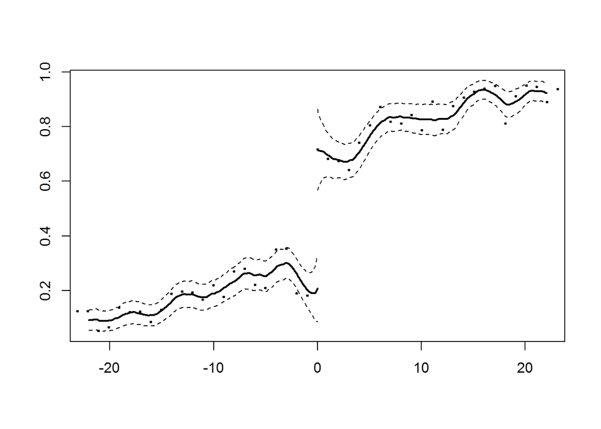

```r
plot(rd,bins=200)
```